# Question2

Li Jiajing

2019/9/28

# Finding #1

```r
age_housing <- group_by(bank,age) %>%
  summarise(n = n(),
            housing_ratio = sum(ifelse(default == "no", 0, 1))/n)
arrange(age_housing) -> finding1
finding1
```

```
## # A tibble: 67 x 3
##      age     n housing_ratio
##    <int> <int>         <dbl>
##  1    19     4       0
##  2    20     3       0
##  3    21     7       0
##  4    22     9       0
##  5    23    20       0.05
##  6    24    24       0.0417
##  7    25    44       0.0227
##  8    26    77       0.0390
##  9    27    94       0.0426
## 10    28   103       0.00971
## # ... with 57 more rows
```

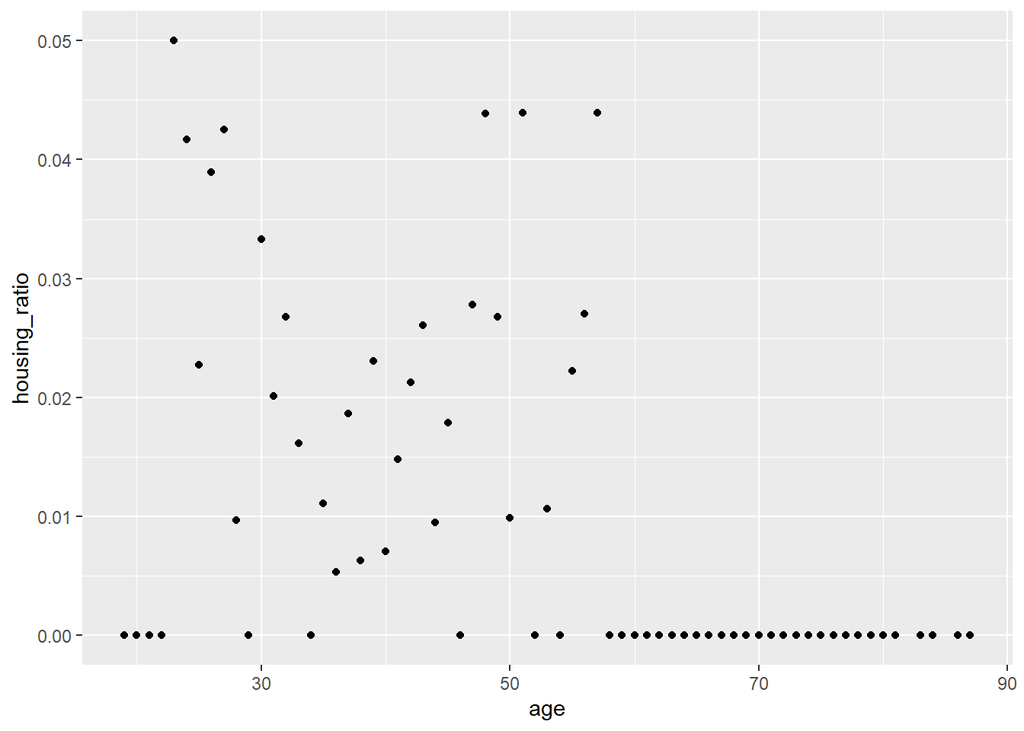

```r
ggplot(finding1, aes(age, housing_ratio)) +
  geom_point()
```

# Finding #2

```r
age_balance <- group_by(bank,age) %>%
  summarise(n = n(),
            balance = mean(balance))
arrange(age_balance) -> finding2
finding2
```

```
## # A tibble: 67 x 3
##      age     n balance
##    <int> <int>   <dbl>
##  1    19     4    394.
##  2    20     3    661.
##  3    21     7   1774.
##  4    22     9   1455.
##  5    23    20   2118.
##  6    24    24    635.
##  7    25    44   1240.
##  8    26    77    789.
##  9    27    94    852.
## 10    28   103   1025.
## # ... with 57 more rows
```

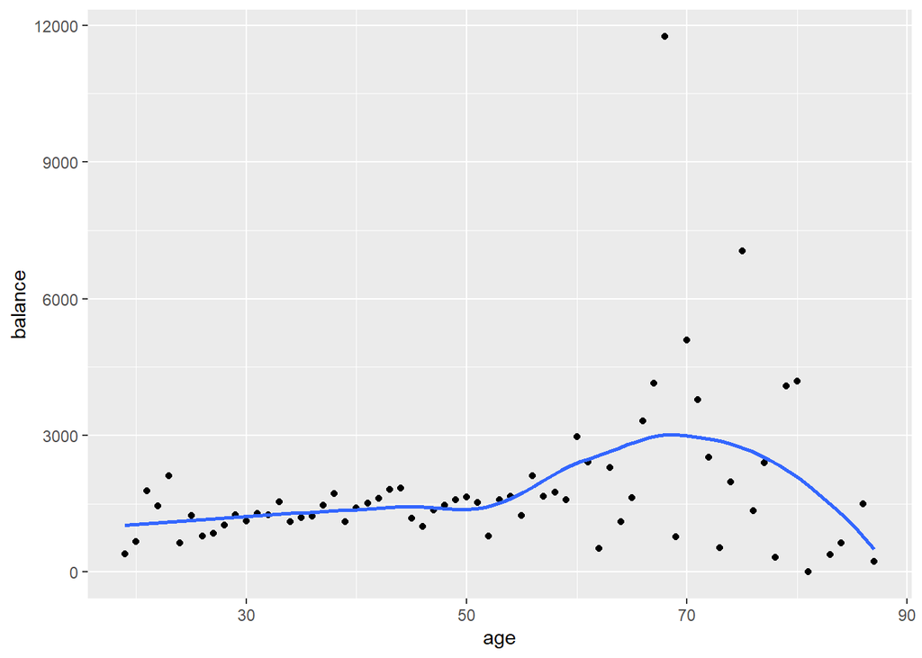

```r
finding2 <- as.data.frame(finding2)
ggplot(finding2, aes(age, balance)) +
  geom_point() +
  geom_smooth(method = "loess", se = FALSE)
```

- Average balance of people above 60 fluctuates more violently than that of people below 60.

# Finding #3

```r
min <- group_by(bank, job) %>%
  summarise("min" = min(balance))
max <- group_by(bank, job) %>%
  summarise("max" = max(balance))
job_balance <- distinct(bank, job) %>% arrange(job)
job_balance <- left_join(job_balance, min, by = "job")
job_balance <- left_join(job_balance, max, by = "job")
job_balance <- mutate(job_balance, "range" = max - min)
arrange(job_balance) -> finding3
finding3
```

```
##              job   min   max range
## 1         admin.  -967 22171 23138
## 2    blue-collar -1400 16353 17753
## 3   entrepreneur -2082 42045 44127
## 4      housemaid  -759 26965 27724
## 5     management -1746 27359 29105
## 6        retired -1206 71188 72394
## 7  self-employed -3313 16430 19743
## 8       services -1202 26394 27596
## 9        student  -230 11555 11785
## 10    technician -1680 27733 29413
## 11    unemployed  -872  9019  9891
## 12       unknown     0  7337  7337
```

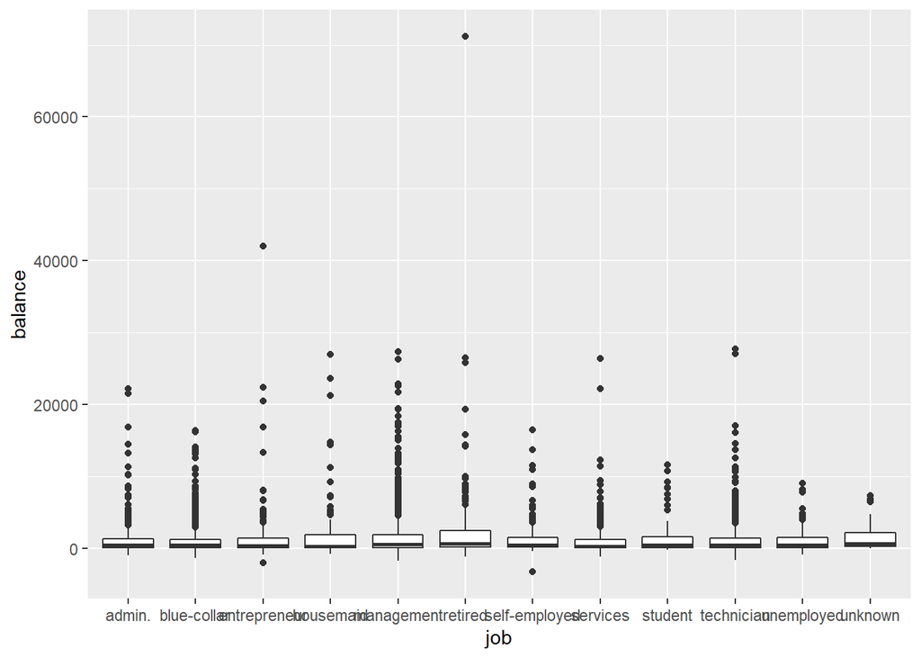

```r
ggplot(bank, aes(job, balance)) +
  geom_boxplot()
```

- Count the minimum, the maximum and the range of balance of each job.
- The highest maximum balance is from retired and the lowest minimum balance is from self-employed.

# Finding #4

```r
job_education <- group_by(bank,job) %>%
  summarise(n = n())
arrange(job_education) -> finding4
finding4
```

```
## # A tibble: 12 x 2
##    job               n
##    <fct>         <int>
##  1 admin.          478
##  2 blue-collar     946
##  3 entrepreneur    168
##  4 housemaid       112
##  5 management      969
##  6 retired         230
##  7 self-employed   183
##  8 services        417
##  9 student          84
## 10 technician      768
## 11 unemployed      128
## 12 unknown          38
```

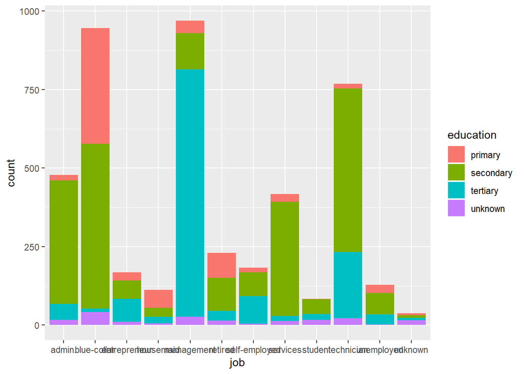

```r
ggplot(bank) +
  geom_bar(aes(x = job, stat = "count", fill = education))
```

- Most people in management are tertiary education.
- The proportion of primary education is significantly higher in blue-collar, housemaid and retired than in other jobs.
- Secondary education takes the largest proportion in people of job admin., blue-collar, retired, services, student, technician and unemployed.

# Finding #5

```r
duration_pdays <- group_by(bank,contact) %>%
  summarise(n = n(),
            duration = mean(duration),
            pdays = mean(pdays))
arrange(duration_pdays) -> finding5
finding5
```

```
## # A tibble: 3 x 4
##   contact       n duration pdays
##   <fct>     <int>    <dbl> <dbl>
## 1 cellular   2896     267. 56.5
## 2 telephone   301     243. 47.1
## 3 unknown    1324     262.  1.46
```

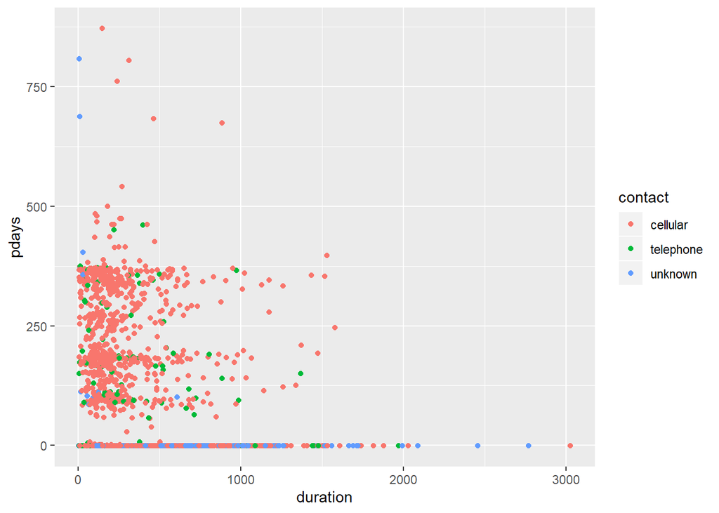

```r
ggplot(bank) +
  geom_point(aes(duration, pdays, color = contact))
```

- Cellular is the most used communication type.
- Ignore the 0 ones, the distribution of number of days that passed by after the client was last contacted from a previous campaign is approximately concentrated in the range of 62.5 to 375.
- People who have “pdays” more than 375 hardly take duration longer than 500 seconds.

# Finding #6

```r
job_marital <- group_by(bank,job) %>%
  summarise(n = n(),
            marital_ratio = sum(ifelse(marital == "married", 1, 0))/n)
arrange(job_marital) -> finding6
finding6
```

```
## # A tibble: 12 x 3
##    job               n marital_ratio
##    <fct>         <int>         <dbl>
##  1 admin.          478         0.556
##  2 blue-collar     946         0.733
##  3 entrepreneur    168         0.786
##  4 housemaid       112         0.75
##  5 management      969         0.575
##  6 retired         230         0.765
##  7 self-employed   183         0.694
##  8 services        417         0.566
##  9 student          84         0.119
## 10 technician      768         0.535
## 11 unemployed      128         0.586
## 12 unknown          38         0.789
```

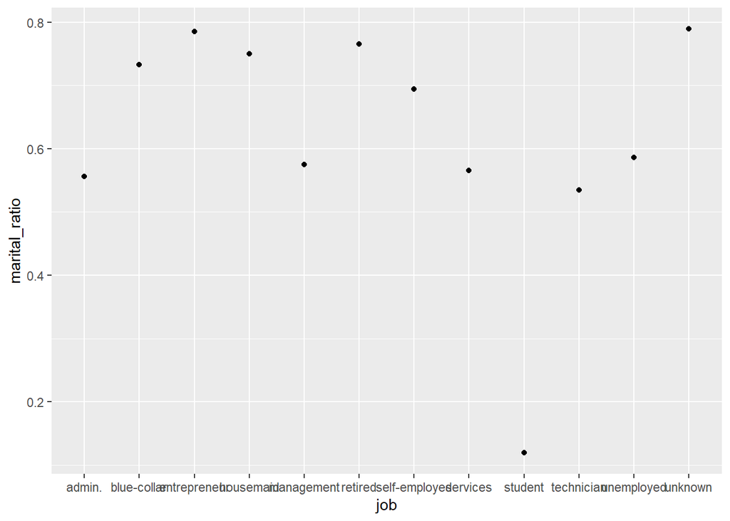

```r
ggplot(finding6, aes(job, marital_ratio)) +
  geom_point()
```

- Students have the lowest marital ratio (of course lol).

# Finding #7

```r
job_count <- group_by(bank,job) %>%
  summarise(n = n())
arrange(job_count) -> finding7
finding7
```

```
## # A tibble: 12 x 2
##    job               n
##    <fct>         <int>
##  1 admin.          478
##  2 blue-collar     946
##  3 entrepreneur    168
##  4 housemaid       112
##  5 management      969
##  6 retired         230
##  7 self-employed   183
##  8 services        417
##  9 student          84
## 10 technician      768
## 11 unemployed      128
## 12 unknown          38
```

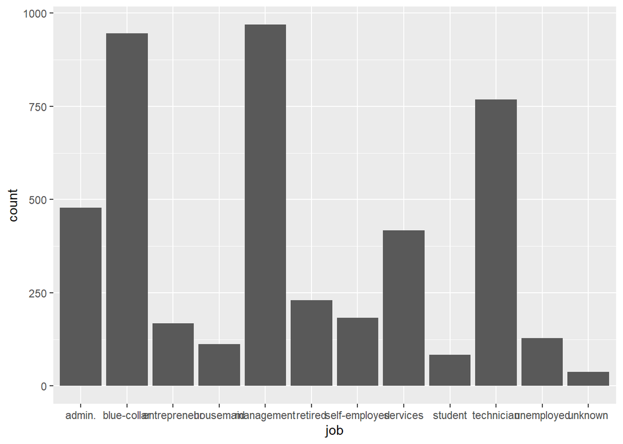

```r
ggplot(bank) +
  geom_bar(aes(x = job))
```

- The job type which includes largest population is management.
- The job type which includes least population except for unknown is student.

# Finding #8

```r
balance_distribution <- group_by(bank,education) %>%
  summarise(n = n(),
            balance = mean(balance))
arrange(balance_distribution) -> finding8
finding8
```

```
## # A tibble: 4 x 3
##   education     n balance
##   <fct>     <int>   <dbl>
## 1 primary     678   1412.
## 2 secondary  2306   1197.
## 3 tertiary   1350   1775.
## 4 unknown     187   1701.
```

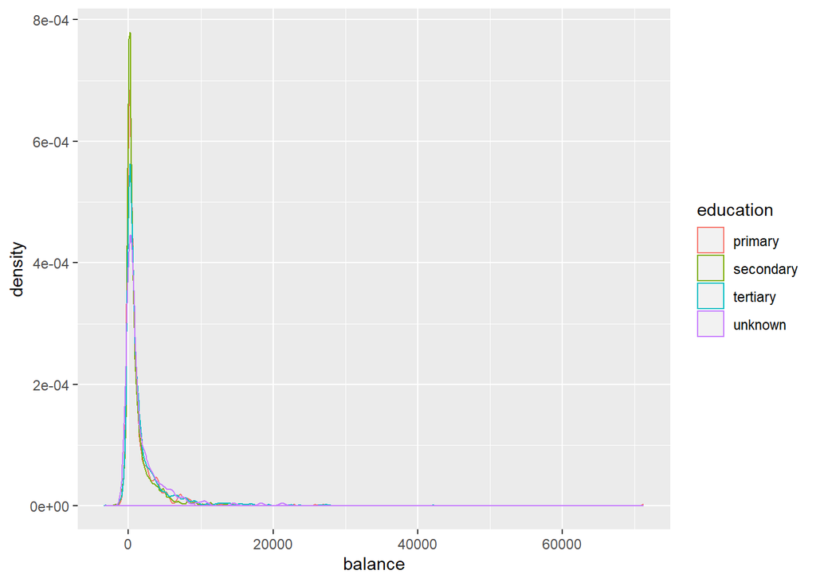

```r
ggplot(bank, aes(balance, color = education)) +
  geom_density()
```

- The average balance of tertiary education people is the highest among all four educations.
- The shapes of the distribution of balance seem to be similar despite the different value of peaks among different educations.

# Finding #9

```r
month_count <- group_by(bank, month) %>%
  summarise(n = n())
arrange(month_count) -> finding9
finding9
```

```
## # A tibble: 12 x 2
##    month     n
##    <fct> <int>
##  1 apr     293
##  2 aug     633
##  3 dec      20
##  4 feb     222
##  5 jan     148
##  6 jul     706
##  7 jun     531
##  8 mar      49
##  9 may    1398
## 10 nov     389
## 11 oct      80
## 12 sep      52
```

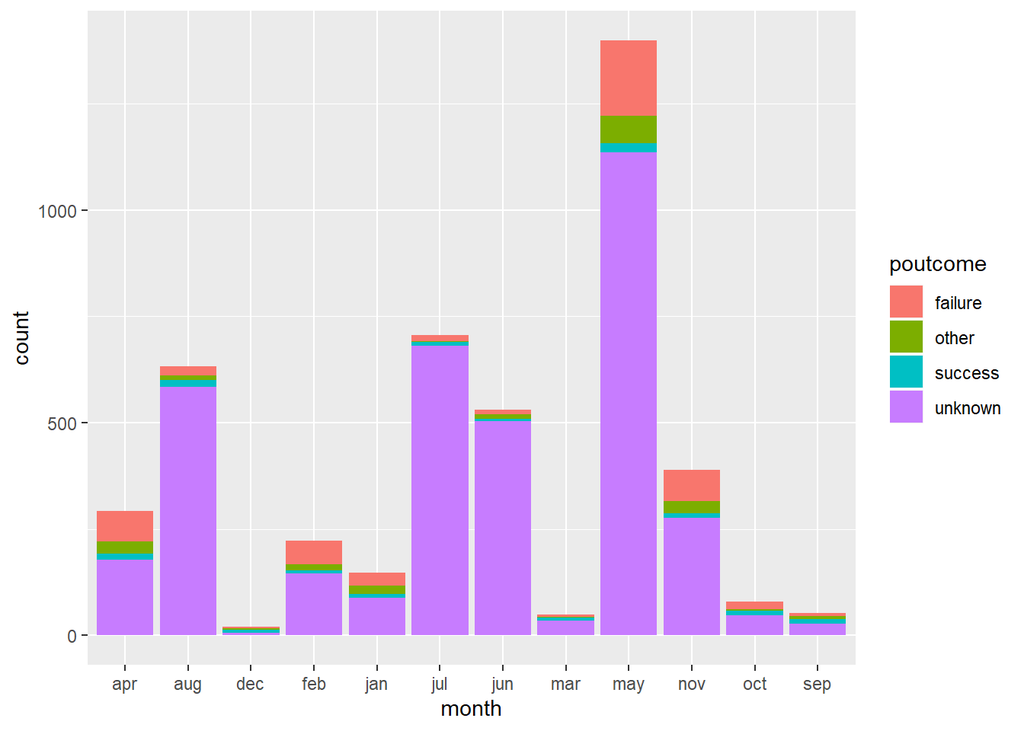

```r
ggplot(bank) +
  geom_bar(aes(x = month, fill = poutcome))
```

# Finding #10

```r
job_loan <- group_by(bank, job) %>%
  summarise(n = n(),
            loan_ratio = sum(ifelse(loan == "yes", 1, 0))/n)
arrange(job_loan) -> finding10
finding10
```

```
## # A tibble: 12 x 3
##    job               n loan_ratio
##    <fct>         <int>      <dbl>
##  1 admin.          478     0.190
##  2 blue-collar     946     0.165
##  3 entrepreneur    168     0.244
##  4 housemaid       112     0.116
##  5 management      969     0.124
##  6 retired         230     0.139
##  7 self-employed   183     0.164
##  8 services        417     0.177
##  9 student          84     0.0119
## 10 technician      768     0.155
## 11 unemployed      128     0.102
## 12 unknown          38     0.0263
```

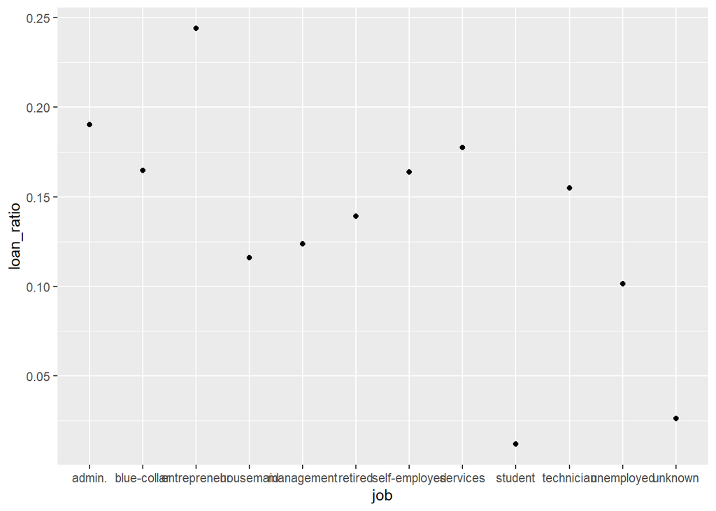

```r
ggplot(finding10, aes(job, loan_ratio)) +
  geom_point()
```

- Entrepreneurs are most likely to have personal loans, while students are least likely to have personal loans.